# RMarkdown Introduction

In this class, we will look at basics of RMarkdown and how to generate an html file from it.

## Installations

Install the package - ‘rmarkdown’ with all its dependencies.

## Code Chunk

this is a sentence

- You can quickly insert chunks like these into your file with
  - the keyboard shortcut Ctrl + Alt + I (OS X: Cmd + Option + I)
  - the Add Chunk `Insert` command in the editor toolbar
  - or by typing the chunk delimiters $```{r}$ and $```$

## How it works

How it works

- When you run render, R Markdown feeds the .Rmd file to knitr ⧉, which executes all of the code chunks and creates a new markdown (.md) document which includes the code and it’s output.
- The markdown file generated by knitr is then processed by pandoc ⧉ which is responsible for creating the finished format. [reference: 1]
- knitr can execute code in many languages besides R. Some of the available language engines include:
  - Python
  - SQL
  - Bash
  - Rcpp
  - Stan
  - JavaScript
  - CSS
- To process a code chunk using an alternate language engine, replace the r at the start of your chunk declaration with the name of the language

```python
print ("This chunk is run using python")
```

```
## This chunk is run using python
```

## Code Chunk Options

Chunk output can be customized with knitr options, arguments set in the {} of a chunk header[reference: 1] :  
* include = FALSE prevents code and results from appearing in the finished file. R Markdown still runs the code in the chunk, and the results can be used by other chunks.  
* echo = FALSE prevents code, but not the results from appearing in the finished file. This is a useful way to embed figures.  
* message = FALSE prevents messages that are generated by code from appearing in the finished file.  
* warning = FALSE prevents warnings that are generated by code from appearing in the finished.

## RMarkdown Basics

### Priting in italics

*Italics*  
*Italics*

### Priting in bold

**Bold**  
**Bold**

### Wiritng Sentences

This is sentence 1.  
This is sentence 2.

### Block Quotes

> This is a block quote

### Embedding links

http://rmarkdown.rstudio.com

RMarkdown with R studio

### Unorderd List

- This is item 1
- This is item 2
  - This is sub-item 2-1

### Orderd List

1. This is item 1
2. This is item 2
   - This is sub-item 2-1

### Superscript

superscript<sup>2</sup>  
10<sup>2</sup>

### Subscript

superscript<sub>2</sub>

### Equations

1. Mean in words
   $${Mean} = \frac{Summation~of~values}{Total~sample~size}$$
2. Mean in mathematical expressions
   $${\mu} = \frac{\sum_{i=1}^n X_i}{n}$$

### Get images from net

Standard Deviation equation

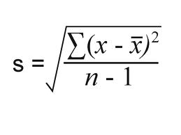

- INSOFE Research

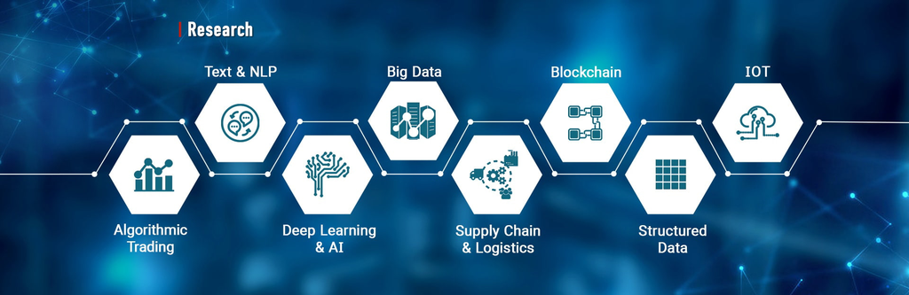

#### Some other commonly used symbols

**Sigma:** $\sigma$  
**Pi:** $\pi$  
**Alpha:** $\alpha$  
**Lambda:** $\lambda$  
**Greater than or equal to:** $\ge$  
**Less than or equal to:** $\le$  
**Plus or minus:** $\pm$

## Lets write some R code now

#### 1. View the data

```r
volcanic_data = faithful
head(volcanic_data)
```

```
##   eruptions waiting
## 1     3.600      79
## 2     1.800      54
## 3     3.333      74
## 4     2.283      62
## 5     4.533      85
## 6     2.883      55
```

Volcanic data table in a neat way

| eruptions | waiting |
| --- | --- |
| 3.600 | 79 |
| 1.800 | 54 |
| 3.333 | 74 |
| 2.283 | 62 |
| 4.533 | 85 |
| 2.883 | 55 |

#### 2. Let us do a scatter plot

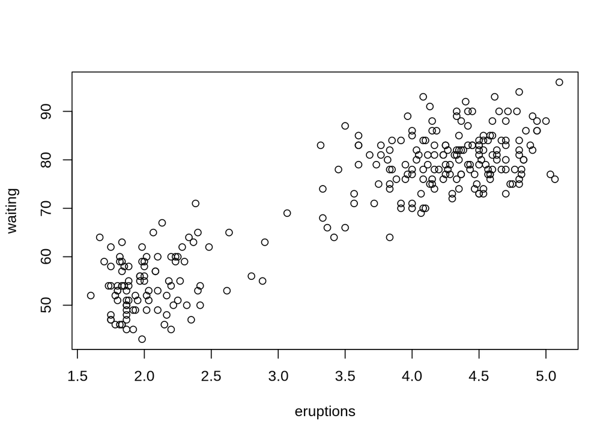

#### 3. What is the summary of the dataset

```r
summary(volcanic_data)
```

```
##    eruptions        waiting
##  Min.   :1.600   Min.   :43.0
##  1st Qu.:2.163   1st Qu.:58.0
##  Median :4.000   Median :76.0
##  Mean   :3.488   Mean   :70.9
##  3rd Qu.:4.454   3rd Qu.:82.0
##  Max.   :5.100   Max.   :96.0
```

## Practice

1. Refer to the lecture notes and write the following equations in Rmarkdown:
- mean
- median
- variance
- standard deviation
- IQR

## Examples of Equations

```r
cars_data = mtcars
summary(mtcars)
```

```
##       mpg             cyl             disp             hp
##  Min.   :10.40   Min.   :4.000   Min.   : 71.1   Min.   : 52.0
##  1st Qu.:15.43   1st Qu.:4.000   1st Qu.:120.8   1st Qu.: 96.5
##  Median :19.20   Median :6.000   Median :196.3   Median :123.0
##  Mean   :20.09   Mean   :6.188   Mean   :230.7   Mean   :146.7
##  3rd Qu.:22.80   3rd Qu.:8.000   3rd Qu.:326.0   3rd Qu.:180.0
##  Max.   :33.90   Max.   :8.000   Max.   :472.0   Max.   :335.0
##       drat             wt             qsec             vs
##  Min.   :2.760   Min.   :1.513   Min.   :14.50   Min.   :0.0000
##  1st Qu.:3.080   1st Qu.:2.581   1st Qu.:16.89   1st Qu.:0.0000
##  Median :3.695   Median :3.325   Median :17.71   Median :0.0000
##  Mean   :3.597   Mean   :3.217   Mean   :17.85   Mean   :0.4375
##  3rd Qu.:3.920   3rd Qu.:3.610   3rd Qu.:18.90   3rd Qu.:1.0000
##  Max.   :4.930   Max.   :5.424   Max.   :22.90   Max.   :1.0000
##        am              gear            carb
##  Min.   :0.0000   Min.   :3.000   Min.   :1.000
##  1st Qu.:0.0000   1st Qu.:3.000   1st Qu.:2.000
##  Median :0.0000   Median :4.000   Median :2.000
##  Mean   :0.4062   Mean   :3.688   Mean   :2.812
##  3rd Qu.:1.0000   3rd Qu.:4.000   3rd Qu.:4.000
##  Max.   :1.0000   Max.   :5.000   Max.   :8.000
```

```r
m = mean(mtcars$cyl)
```

The mean of number of cylinders is:
$$\bar{cyl} = 6.1875$$

## References:

1. https://www.rstudio.com/wp-content/uploads/2015/02/rmarkdown-cheatsheet.pdf
2. http://rmarkdown.rstudio.com